# BART

Sammie Liang

July 15, 2017

```r
library(fields)
library(png)
```

# Questions to Answer/Goals

- **1.** Which day of the week is the busiest?
- **2.** Which time of the day is busiest?
- **3.** Which BART station is the busiest?

# Data Preparation

- First, read in the data for both the “station_info.csv”, which contains descriptions and full names of each of the stations, as well as “date-hour-soo-dest-2017.csv”, which contains BART travel data in the first five months of 2017.

```r
#Both datasets were taken from https://www.kaggle.com/saulfuh/bart-ridership

stationInfo = read.csv("station_info.csv")
bartTravel = read.csv("date-hour-soo-dest-2017.csv")
```

- The day, month, and year of the bartTravel dataset need to be formatted correctly. In addition, the encoding of name of the Abbreviation variable was not ideal, so I just created a new variable name. There was a discrepancy between the abbreviation for Warm Springs in the BART data and the station data, so I updated the station data to match that of the BART data.

```r
bartTravel$Day = as.factor(weekdays(as.Date(bartTravel$DateTime, format = "%Y-%m-%d")))
bartTravel$Month = as.factor(months(as.Date(bartTravel$DateTime, format = "%Y-%m-%d")))
bartTravel$Hour = as.factor(substring(bartTravel$DateTime, 12, 16))
stationInfo$Abb = stationInfo$ï..Abbreviation
stationInfo$ï..Abbreviation = NULL
levels(stationInfo$Abb)[levels(stationInfo$Abb) == "WARM"] = "WSPR"
```

```r
names(bartTravel)
```

```
## [1] "Origin"      "Destination" "Throughput"  "DateTime"    "Day"
## [6] "Month"       "Hour"
```

```r
names(stationInfo)
```

```
## [1] "Description" "Location"    "Name"        "Abb"
```

# Question 1: Which day of the week is busiest?

**1.1 Organizing Data**

- I will compute the busiest day of the week based on the sum of both destiation and origin data. I split the ‘bartTravel’ data according to days of the week, the origin, as well as destination separately.

```r
days = c("Monday", "Tuesday", "Wednesday", "Thursday", "Friday", "Saturday", "Sunday")

ridesByDay = split(bartTravel, f=bartTravel$Day)
dayRides = vector(length=length(days))

for (i in 1:length(days))
{
  dayData = subset(ridesByDay, names(ridesByDay) == days[i])[[1]]
  dayRides[i] = sum(dayData$Throughput)
}
names(dayRides) = days
dayRides
```

```
##    Monday   Tuesday Wednesday  Thursday    Friday  Saturday    Sunday
##   6595815   7627646   7750186   7347484   6769222   3297741   2152901
```

**1.2 Visualiziation**

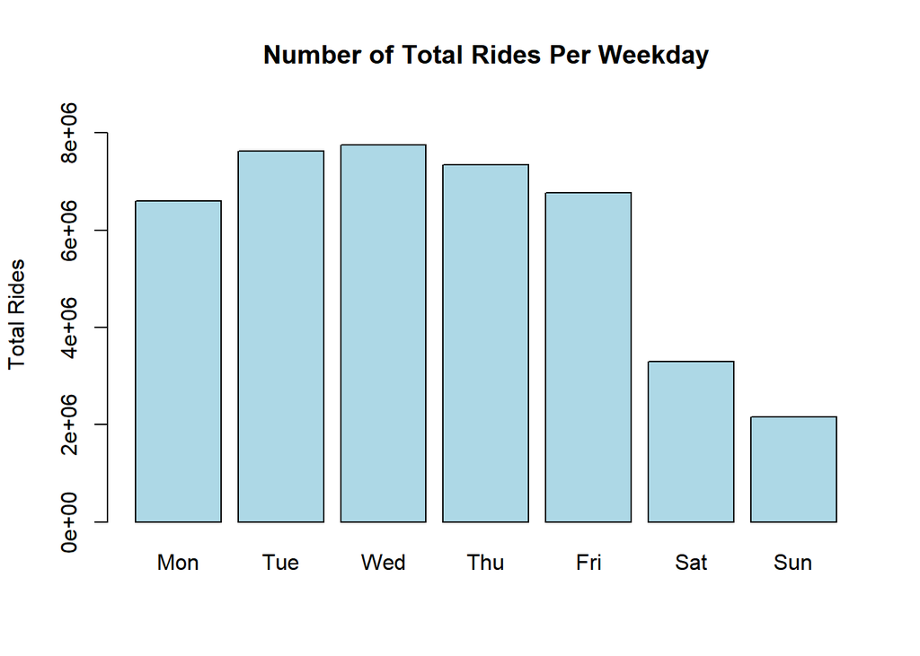

```r
barplot(dayRides, names.arg=substring(names(dayRides),1,3), col="light blue", ylim=c(0,max(dayRides)*1.1), main="Number of Total Rides Per Weekday", ylab="Total Rides")
```

**1.3 Conclusion**

- From the visualization, we conclude that Wednesday is the busiest day of the week, with Sunday being the least busy. Overall, the weekdays are much more heavily populated than the weekends, which makes sense, given people ride BART to school and to work on the weekdays.

# Question 2: Which time of day is busiest?

**2.1 Organizing Data**

- We can take it a step further, and break down what the busiest hour of the day to ride BART is.

```r
hours = levels(bartTravel$Hour)
dayRidesByHour = matrix(nrow = length(days), ncol = length(hours))
for (i in 1:length(days))
{
  dayData = subset(ridesByDay, names(ridesByDay) == days[i])[[1]]
  for (j in 1:length(hours))
  {
    dayRidesByHour[i,j] = sum(dayData$Throughput[dayData$Hour == hours[j]])
  }
}
rownames(dayRidesByHour) = days
colnames(dayRidesByHour) = hours
dayRidesByHour
```

```
##           00:00 01:00 02:00 03:00 04:00 05:00  06:00  07:00  08:00  09:00
## Monday    27115  3951    18    46 10558 78313 222721 525024 781440 602829
## Tuesday   33326  4930     4    54 13817 95550 271546 636747 918024 715599
## Wednesday 38198  5673     8    58 13225 99770 268691 624834 927048 691647
## Thursday  40283  5887    13    45 11818 93179 253615 588833 863072 651739
## Friday    43753  6794    44    39 10396 81124 221492 496127 737803 573213
## Saturday  72608 13355    24     3     1   179  30906  73067 117504 158616
## Sunday    63751 26907 10163  3744   283    11     33    373  66676 100364
##            10:00  11:00  12:00  13:00  14:00  15:00  16:00  17:00  18:00
## Monday    300374 203191 197047 202344 224645 305367 477137 770720 735571
## Tuesday   323667 215987 205331 210528 243996 338577 551220 890746 860937
## Wednesday 340338 225465 216905 221811 253401 342671 548621 897967 870958
## Thursday  315630 217490 209724 214019 248184 336123 529365 844258 797890
## Friday    304723 222160 214786 228782 265673 349091 524134 765437 686069
## Saturday  186753 213033 218436 233555 236100 238780 260768 273117 254462
## Sunday    128643 149918 160594 163758 160536 161018 171166 178717 156757
##            19:00  20:00  21:00  22:00  23:00
## Monday    385093 203140 145838 119912  73421
## Tuesday   455351 230444 171110 141590  98565
## Wednesday 465093 242866 185871 158457 110610
## Thursday  446236 234869 185429 151567 108216
## Friday    382067 207634 163018 149269 135594
## Saturday  208041 150579 126000 125993 105861
## Sunday    130474 107664  85193  73407  52751
```

```r
ridesByHour = colSums(dayRidesByHour)
names(ridesByHour) = hours
```

**2.2 Visualization**

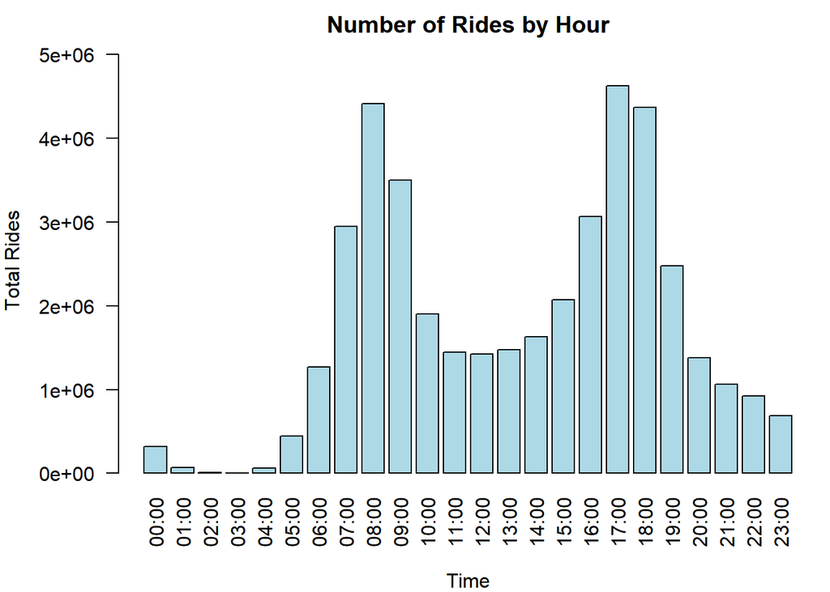

```r
par(mar=c(5,5,2,0.5))
barplot(ridesByHour, names.arg=names(ridesByHour), col="light blue", ylim=c(0,max(ridesByHour))*1.1, main="Number of Rides by Hour", las=2)
mtext(side=2, text = "Total Rides", line=4)
mtext(side=1, text="Time", line=4)
```

**2.4 Another Visualization**

- I wanted to explore a combined visualization of the days of the week with the hours of the day.

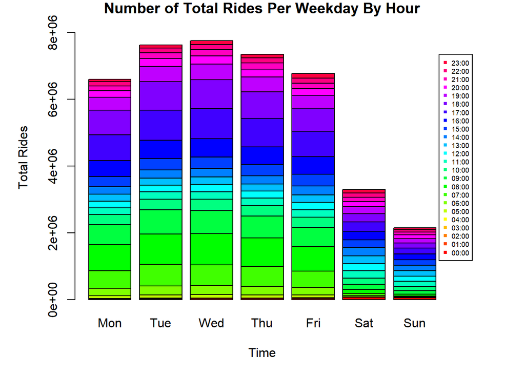

```r
par(mar=c(5,5,1,5))
barplot(as.matrix(as.data.frame(t(dayRidesByHour))), col=rainbow(24), names.arg=substring(rownames(dayRidesByHour),1,3), ylim=c(0,max(rowSums(dayRidesByHour))*1.1), main="Number of Total Rides Per Weekday By Hour")
legend("right", legend=rev(colnames(dayRidesByHour)), col=rev(rainbow(24)),pch=15, xpd=TRUE, cex=0.55, inset=-0.06)
mtext(side=2, text = "Total Rides", line=3)
mtext(side=1, text="Time", line=3)
```

- Just visually, the ratio of the popularity of the hours to the overall busyness seem pretty proportional.

# Question 3: Which BART station is the busiest?

**3.1 Organizing Data**

- I split the day according to origin station data and destination station data to make the data easier to deal with.

```r
allUniqueStations = levels(bartTravel$Origin)

stationData.arr = split(bartTravel, bartTravel$Destination)
stationData.depart = split(bartTravel, bartTravel$Origin)

ridesByStation.arr = vector(length=length(allUniqueStations))
ridesByStation.depart = vector(length=length(allUniqueStations))
for (i in 1:length(allUniqueStations))
{
  arr = stationData.arr[[i]]
  depart = stationData.depart[[i]]
  ridesByStation.arr[i] = sum(arr$Throughput)
  ridesByStation.depart[i] = sum(depart$Throughput)
}

names(ridesByStation.arr) = allUniqueStations
names(ridesByStation.depart) = allUniqueStations

stationData = ridesByStation.arr + ridesByStation.depart
names(stationData) = allUniqueStations
```

```r
totalRidesByStation = sort(stationData, decreasing=TRUE)
fiveMostPopularStations = vector(length=5)

for (i in 1:5)
{
  fiveMostPopularStations[i] = as.character(stationInfo$Name[stationInfo$Abb == names(totalRidesByStation)[i]])
}

fiveMostPopularStations
```

```
## [1] "Embarcadero (EMBR)"
## [2] "Montgomery St. (MONT)"
## [3] "Powell St. (POWL)"
## [4] "Civic Center/UN Plaza (CIVC)"
## [5] "12th St. Oakland City Center (12TH)"
```

**3.2 Visualization**

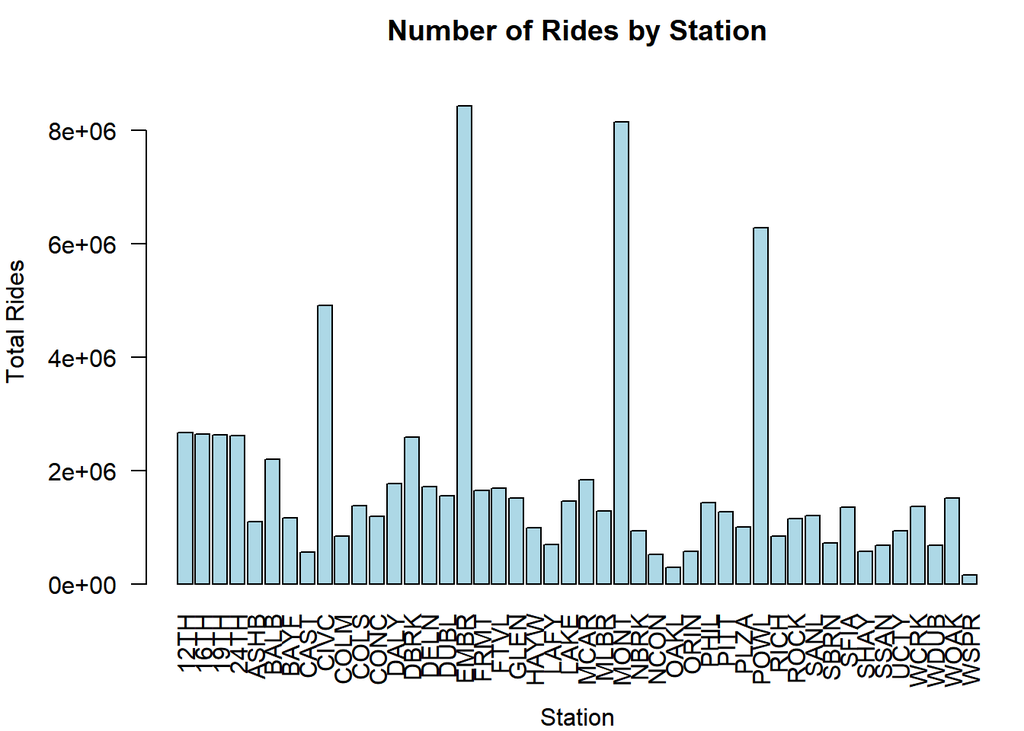

```r
par(mar=c(5,5,2,0.5))
barplot(stationData, names.arg=names(stationData), col="light blue", ylim=c(0,max(stationData))*1.1, main="Number of Rides by Station", las=2)
mtext(side=2, text = "Total Rides", line=4)
mtext(side=1, text="Station", line=4)
```

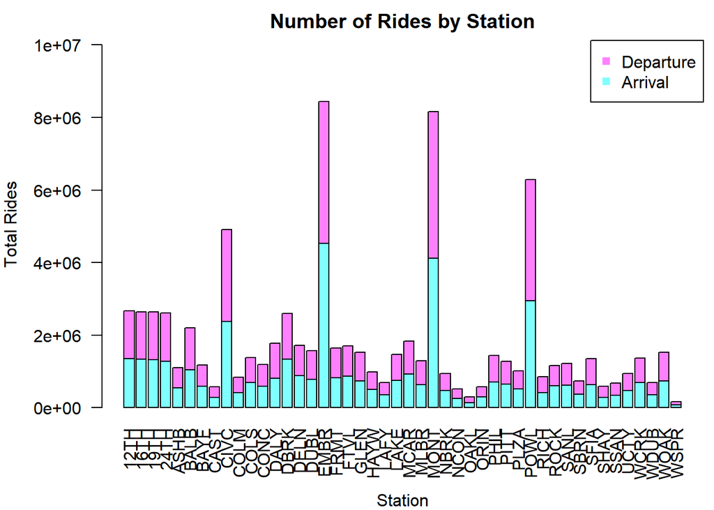

```r
par(mar=c(5,5,2,0.5))
stationData.arr.depart = cbind(ridesByStation.arr, ridesByStation.depart)
colnames(stationData.arr.depart) = c("Arrival", "Departure")

barplot(as.matrix(as.data.frame(t(stationData.arr.depart))), col=cm.colors(2), names.arg=rownames(stationData.arr.depart), ylim=c(0,max(rowSums(stationData.arr.depart))*1.2), main="Number of Rides by Station", las=2)
mtext(side=2, text = "Total Rides", line=4)
mtext(side=1, text="Station", line=4)
legend("topright", legend=rev(colnames(stationData.arr.depart)), col=rev(cm.colors(2)),pch=15, xpd=TRUE)
```

```r
ratio.depart = (ridesByStation.depart)/(ridesByStation.arr + ridesByStation.depart)
ratio.arr = (ridesByStation.arr)/(ridesByStation.arr + ridesByStation.depart)
sum(ratio.depart > 0.55)
```

```
## [1] 0
```

```r
sum(ratio.arr > 0.55)
```

```
## [1] 0
```

**3.3 Conclusions**

- The five most popular stations are Embarcadero (EMBR), Montgomery Street (MONT), Powell Street (POWL), Civic Center (CIVC), and 12th Street (12TH). Looking at the graphical visualization, the four most popular stations are significantly dense so than the rest of the stations. In addition, within each station, there doesn’t seem to be a big difference between the arrival rides and the departure rides, considering that neither one are greater than the other by at least 55%.

**3.4 Another Visualization**

```r
dayRidesByStation = matrix(nrow=length(allUniqueStations), ncol=length(days))
for (i in 1:length(allUniqueStations))
{
  station.arr = stationData.arr[[i]]
  station.depart = stationData.depart[[i]]

  for (j in 1:length(days))
  {
      dayRidesByStation[i,j] = sum(station.arr$Throughput[station.arr$Day == days[j]])
      dayRidesByStation[i,j] = sum(station.depart$Throughput[station.depart$Day == days[j]])
  }
}

rownames(dayRidesByStation) = allUniqueStations
colnames(dayRidesByStation) = days
```

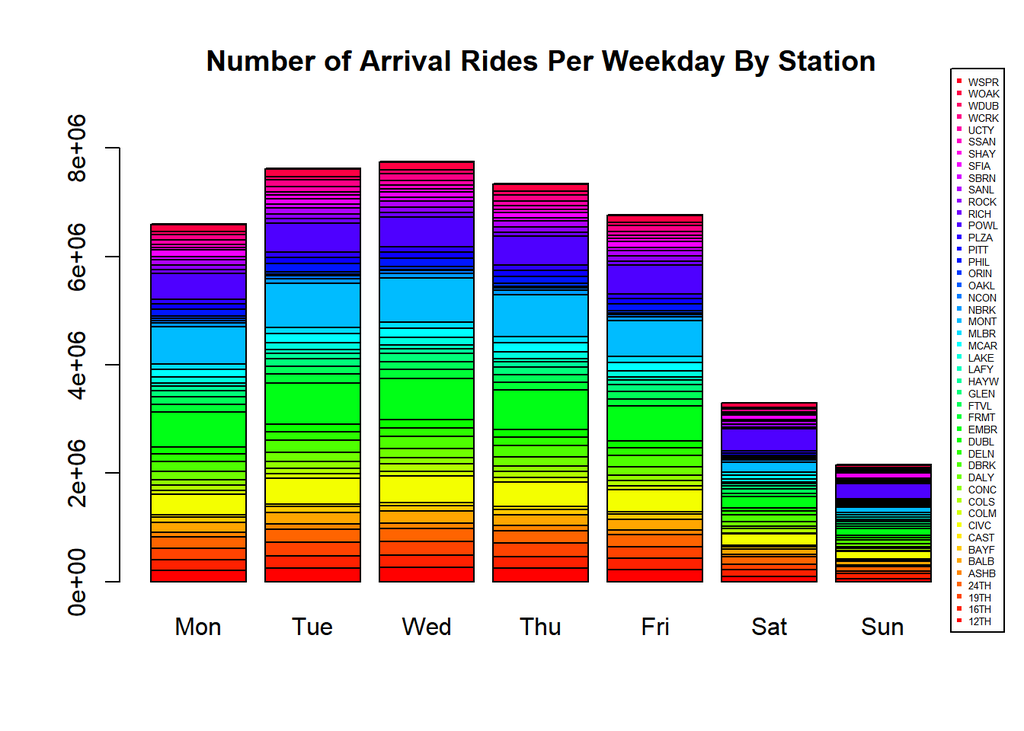

```r
barplot(as.matrix(as.data.frame(dayRidesByStation)), col=rainbow(46), names.arg=substring(colnames(dayRidesByStation),1,3), ylim=c(0,max(colSums(dayRidesByStation))*1.1), main="Number of Arrival Rides Per Weekday By Station")
legend("right", legend=rev(rownames(dayRidesByStation)), col=rev(rainbow(46)),pch=15, xpd=TRUE, cex=0.41, inset=-0.05)
```

- This visualization showing the popularity of each day of the week partitioned by each station is fairly parallel to the hour-partitioned graph in 2.4. Each station’s daily density is proportional with the daily total rides. The one exception is Powell during the weekends. Whereas all of the other stations’s total rides are reduced significantly, Powell’s does not deviate quite as much.

# Visualizing in Zones

- The plot by station is difficult to visualize, so I split the stations according to the zones defined by BART. Since the zones are broken up spatially, it is likely that if a station is popular, the stations around it are popular as well.

[figure not shown]

```r
#Image taken from the BART website
zone_img = download.file("https://www.bart.gov/sites/default/files/images/basic_page/zone_map.png", destfile="bart_zones.png", mode="wb")
zone_img = readPNG("bart_zones.png")
plot(0:100,0:100,type="n", ann=FALSE, axes=FALSE)
rasterImage(zone_img, 0, 0, 60, 100)
```

**Organizing Data**

```r
zone1 = c("WOAK","MCAR","19TH","12TH","LAKE","FTVL","COLS", "OAKL")
zone2c = c("PITT","NCON","CONC","PHIL","WCRK","LAFY","ORIN","ROCK")
zone2r = c("RICH","DELN","PLZA","NBRK","DBRK","ASHB")
zone3 = c("SANL","BAYF","CAST","WDUB","DUBL","HAYW","SHAY","UCTY","FRMT", "WSPR")
zone4 = c("EMBR","MONT", "POWL","CIVC","16TH", "24TH","GLEN","BALB")
zone5 = c("DALY","COLM","SSAN","SBRN","MLBR", "SFIA")

zones = vector(mode="list", length=length(6))
zones[[1]] = zone1
zones[[2]] = zone2c
zones[[3]] = zone2r
zones[[4]] = zone3
zones[[5]] = zone4
zones[[6]] = zone5

zones.dest = matrix(nrow=length(zones), ncol=length(days))

for (i in 1:length(zones))
{
    zones.dest[i,] = colSums(dayRidesByStation[(rownames(dayRidesByStation) %in% zones[[i]]),])
}

rownames(zones.dest) = c("Zone 1", "Zone 2c", "Zone 2r", "Zone 3", "Zone 4", "Zone 5")
colnames(zones.dest) = days
```

- Just briefly scanning the zones, the four most popular stations that were calculated before are within the same zone, more specifically the San Francisco area, which makes a lot of intuitive sense.

**Visualization**

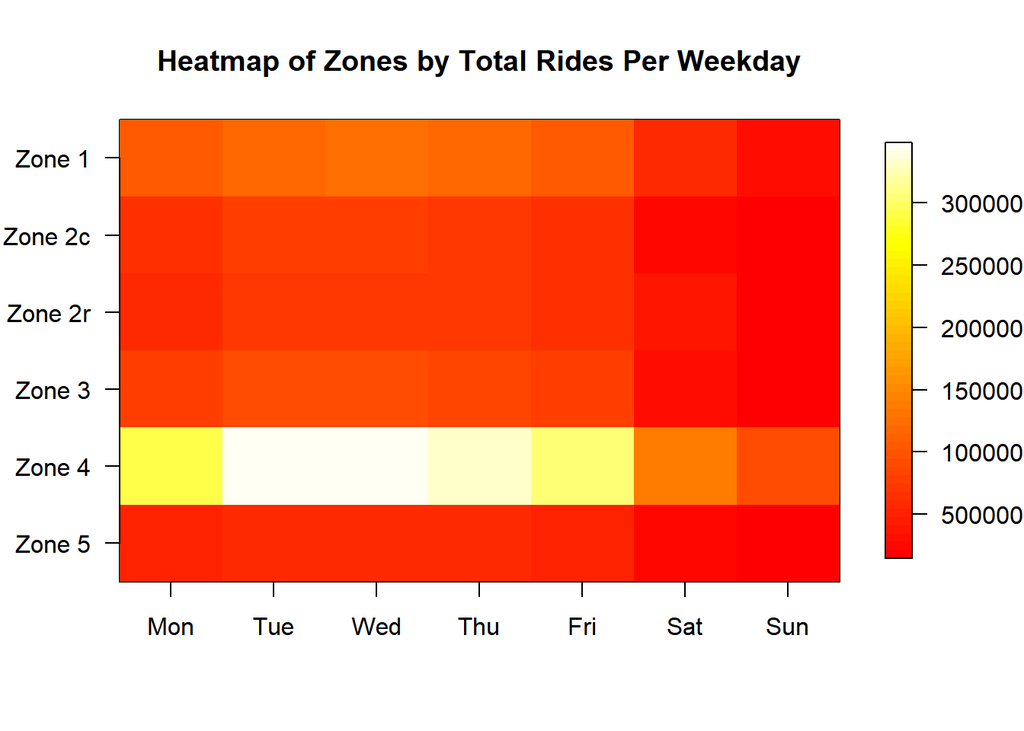

```r
rotate90 = function(a) { t(a[nrow(a):1,]) }
fields::image.plot(rotate90(zones.dest), col = heat.colors(50),xaxt="n", yaxt="n", main="Heatmap of Zones by Total Rides Per Weekday")
image(rotate90(zones.dest), col=heat.colors(50),axes=FALSE,add=TRUE)
axis(2, at=seq(0,1,length.out=length(rownames(zones.dest))), labels=rev(paste(rownames(zones.dest))), las=2)
axis(1, at=seq(0,1,length.out=length(substring(colnames(zones.dest),1,3))), labels=substring(colnames(zones.dest),1,3))
```

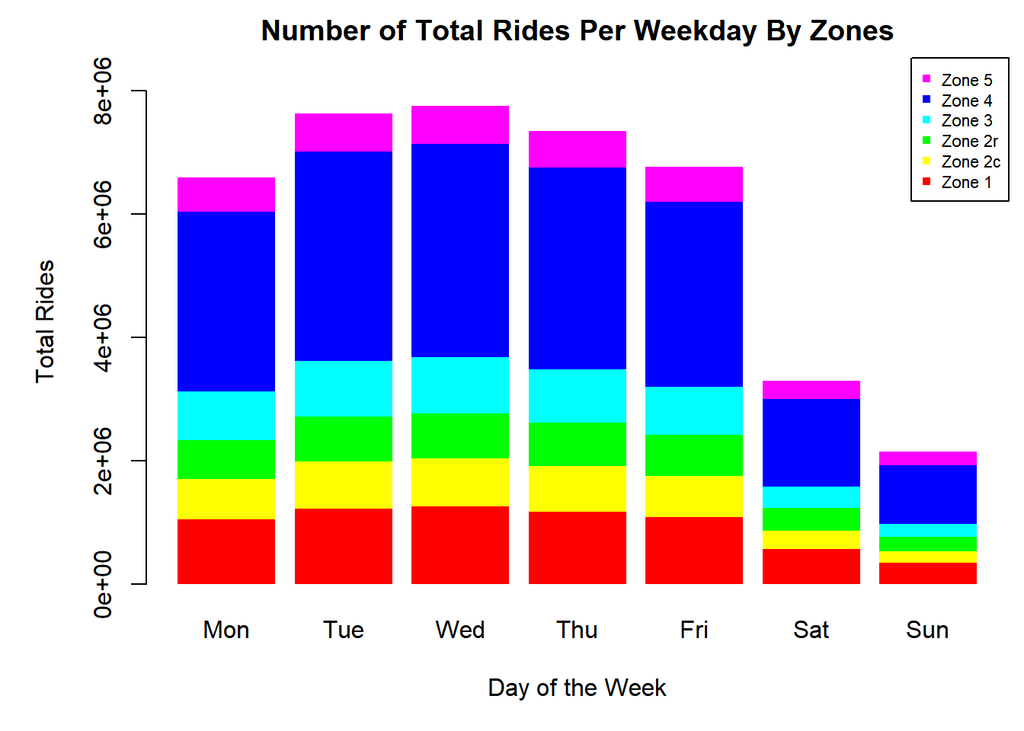

```r
par(mar=c(5,5,2,0.5))
barplot(as.matrix(as.data.frame(zones.dest)), col=rainbow(6), names.arg=substring(colnames(zones.dest),1,3), ylim=c(0,max(colSums(zones.dest))*1.1), main="Number of Total Rides Per Weekday By Zones", border=NA)
mtext(side=2, text = "Total Rides", line=3)
mtext(side=1, text="Day of the Week", line=3)
legend("topright", legend=rev(rownames(zones.dest)), col=rev(rainbow(6)),pch=15, xpd=TRUE, cex=0.7)
```

**Conclusions**

From the stacked bar plot, it is evident that the two most popular zones are 4 and 1, which are the San Francisco area and the downtown Oakland area respectively. The heat map visually shows how significant the difference between the San Francisco zone and all of the other zones is. It also shows that the best time to catch the BART to San Francisco would be Sunday.